# Class 03

# Packages

Packages (there’s a lot!)

```r
library(tidyverse)
library(lmtest)  # robust SEs
library(sandwich)
library(countrycode) # for matching country names
library(dataverse)   # for accessing replication data on the dataverse
library(WDI)         # World Developement indicators API
library(ggdist)      # Distribution plots
library(marginaleffects)  # marginal effects estimation tools
library(ggfortify) # ggplot style diagnostics
library(car)         # regression diagnistcs
library(huxtable)  # regression output formatting
```

Also, if you don’t have it already, you’ll want to install the `vdemdata` package. This provides easy access to the latest version of the Varieties of Democracy Dataset :

```r
devtools::install_github("vdeminstitute/vdemdata")
```

# Preparing the data

First, we need to do a little data set construction. This is messy, but rather than leave it out I figured I would show it here to give a sense of the process.

We’ll pull from three difference data sources:

- Varieties of Democracy (V-DEM) for global data on democracy and governance ([codebook](https://www.v-dem.net/static/website/img/refs/codebookv12.pdf))
- World Bank Data world ([information](https://databank.worldbank.org/)) ([R package info](https://github.com/vincentarelbundock/WDI)) for economic indicators
- Global Legislators Data ([dataverse](https://dataverse.harvard.edu/dataset.xhtml?persistentId=doi:10.7910/DVN/U1ZNVT)) ([codebook](https://dataverse.harvard.edu/file.xhtml?fileId=10595363&version=1.0)) for information about the ages of legislators

```r
# get global legislators data
gld <- get_dataframe_by_name(
  filename = "global_legislator_database.tab",
  dataset = "10.7910/DVN/U1ZNVT",
  server = "dataverse.harvard.edu")


# aggregate to get average age for each legislature
gld_agg <- gld |>
  group_by(country_name, year_of_election) |>
  summarise(
    nleg = n(),
    mean_age = mean(year_of_election - year(dob), na.rm = T)
  )|>
  # add VDEM matching code
  mutate(vdem_code =   countrycode(country_name, origin = 'country.name', destination = 'vdem'))


# get vdem data. Filter by year and select usefil columns
vdem<-vdemdata::vdem|>
  filter(year>=2010)|>
  select(year, country_id, e_pelifeex, v2elpubfin,v2xnp_client,e_regionpol, v2elparlel, v2x_corr, v2x_polyarchy)|>
  mutate(electoral_system = factor(v2elparlel, labels=c("Majoritarian", "Proportional", "Mixed","Other")),

         )|>
  rename(public_finance = v2elpubfin)


# get data from the world bank WDI
wdi_data<-WDI(indicator=c('gdp_pcap'= 'NY.GDP.PCAP.KD',
                          'gini' = 'SI.POV.GINI',
                          'life_expectancy'  = 'SP.DYN.LE00.IN',
                          'pop_over_65'= 'SP.POP.65UP.TO.ZS'),
                start=2010, end=2023
)


# Add a vdem matching code
wdi_data<-wdi_data|>
  mutate(vdem_code =   countrycode(country, origin='country.name', destination='vdem'))


# Join everything on country and year. inner_join means we're dropping anything
# without a match, be careful with this (left joins are often better)

gld_joined<-gld_agg|>
  inner_join(vdem, by=join_by(vdem_code == country_id, year_of_election == year))|>
  inner_join(wdi_data, by = join_by(vdem_code == vdem_code, year_of_election == year) )
```

# Research Question

The U.S. has a lot of old people in congress. Why is this? How do we compare to other states? And are their structural features that might explain why we’ve got so many people born before the invention of commerically viable color television in positions of power?

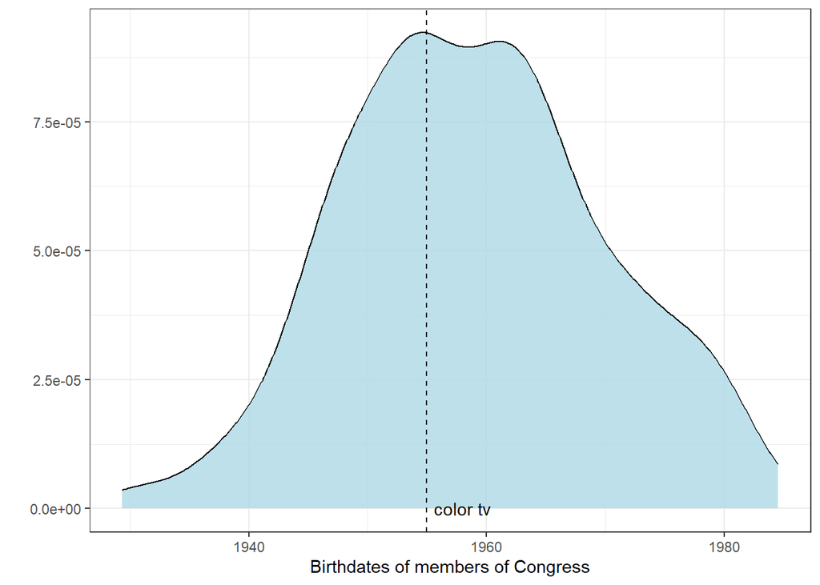

```r
gld|>
  filter(country_name=="United States")|>
  ggplot(aes(x=dob)) +
  geom_density(fill='lightblue', alpha=.8) +
  geom_vline(xintercept = as.Date("1954-12-17"), lty=2) +
  annotate("text", x=as.Date("1957-12-31"), y=0, label="color tv") +
  theme_bw() +
  xlab("Birthdates of members of Congress") +
  ylab("")
```

# Initial models

```r
stats = c("N. obs." = "nobs",
               "R squared" = "r.squared",
               "F statistic" = "statistic",
               "BIC")
ci_level = .95
error_format = "[{conf.low} - {conf.high}]"


model_0<-lm(mean_age ~ life_expectancy + gdp_pcap,
          data=gld_joined)
model_1<-lm(mean_age ~ life_expectancy + log(gdp_pcap), data =gld_joined)
model_2<-lm(mean_age ~ life_expectancy + log(gdp_pcap) + public_finance , data =gld_joined)


huxreg('baseline model' = model_0,
       'logged IV model' = model_1,
       'public_finance' = model_2,
       statistics = stats,
       ci_level =ci_level,
       error_format =error_format,
       note = "95% ci in brackets"
       )
```

|  | baseline model | logged IV model | public_finance |
| --- | --- | --- | --- |
| (Intercept) | 57.887 *** | 57.256 *** | 50.448 *** |
|  | [48.943 - 66.831] | [49.987 - 64.526] | [42.604 - 58.291] |
| life_expectancy | -0.114 | -0.234 * | -0.177 * |
|  | [-0.242 - 0.014] | [-0.413 - -0.056] | [-0.348 - -0.006] |
| gdp_pcap | 0.000 |  |  |
|  | [-0.000 - 0.000] |  |  |
| log(gdp_pcap) |  | 1.092 * | 1.467 ** |
|  |  | [0.039 - 2.145] | [0.453 - 2.480] |
| public_finance |  |  | -0.922 *** |
|  |  |  | [-1.440 - -0.405] |
| N. obs. | 94 | 94 | 94 |
| R squared | 0.035 | 0.070 | 0.184 |
| F statistic | 1.639 | 3.429 | 6.753 |
| BIC | 525.812 | 522.308 | 514.598 |
| 95% ci in brackets |  |  |  |

## Checks

At a minimum, we should look for evidence of:

- non-normality
- heteroskedasticity
- influential observations
- non-linearity

A visual check of our residuals is a good starting point for investigating these issues:

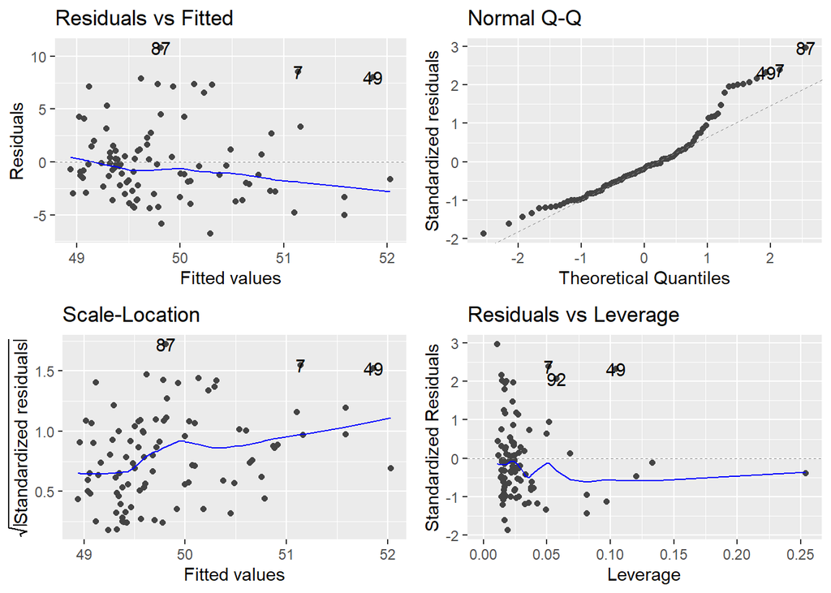

```r
autoplot(model_0)
```

The Breusch–Pagan test gives us a test against a null hypothesis that the data are homoscedastic:

```r
ncvTest(model_0)
```

```
Non-constant Variance Score Test
Variance formula: ~ fitted.values
Chisquare = 6.414001, Df = 1, p = 0.011322
```

We might also want to check for evidence of multicollinearity, although this appears to be less of a problem here:

```r
vif(model_0)
```

```
life_expectancy        gdp_pcap
       1.725716        1.725716
```

# Question 1

Based on the analyses above, do you see evidence to support any changes to the model such as transforming variables?

```r
# code here
```

# Robust Standard Errors

Since we have some clear evidence of heteroskedasticity, it probably makes sense to go ahead and use heteroskedasticity robust standard errors, which relax the assumption of constant variance:

```r
m_0<-coeftest(model_0, vcov = vcovHC(model_0, "HC0"))
m_1<-coeftest(model_1, vcov = vcovHC(model_1, "HC0"))
m_2<-coeftest(model_2, vcov = vcovHC(model_2, "HC0"))
```

## Model Comparison

Which models are better? We can compare models using BIC/AIC (lower scores mean better models, all else equal)

```r
huxreg('baseline model' = m_0,
       'logged IV model' = m_1,
       'public_finance' = m_2,
       statistics = stats,
       ci_level =ci_level,
       error_format =error_format,
       note = "95% ci in brackets"
       )
```

|  | baseline model | logged IV model | public_finance |
| --- | --- | --- | --- |
| (Intercept) | 57.887 *** | 57.256 *** | 50.448 *** |
|  | [47.767 - 68.008] | [48.693 - 65.820] | [38.874 - 62.022] |
| life_expectancy | -0.114 | -0.234 * | -0.177 |
|  | [-0.253 - 0.025] | [-0.427 - -0.041] | [-0.390 - 0.036] |
| gdp_pcap | 0.000 |  |  |
|  | [-0.000 - 0.000] |  |  |
| log(gdp_pcap) |  | 1.092 * | 1.467 ** |
|  |  | [0.031 - 2.153] | [0.508 - 2.425] |
| public_finance |  |  | -0.922 ** |
|  |  |  | [-1.579 - -0.266] |
| N. obs. | 94 | 94 | 94 |
| BIC | 525.812 | 522.308 | 514.598 |
| 95% ci in brackets |  |  |  |

Or, if the models are nested, we can compare using F-tests

```r
anova(model_0, model_1)
```

| Res.Df | RSS | Df | Sum of Sq | F | Pr(>F) |
| --- | --- | --- | --- | --- | --- |
| 91 | 1.22e+03 |  |  |  |  |
| 91 | 1.17e+03 | 0 | 44.6 |  |  |

```r
anova(model_1, model_2)
```

| Res.Df | RSS | Df | Sum of Sq | F | Pr(>F) |
| --- | --- | --- | --- | --- | --- |
| 91 | 1.17e+03 |  |  |  |  |
| 90 | 1.03e+03 | 1 | 144 | 12.5 | 0.000636 |

## Equivalence Testing

What if we want to rule out the possibility that the a PR system would result in younger legislators relative to a majoritarian system? We can see here that the effect is not statistically significant.

```r
model<-lm(mean_age ~
            life_expectancy +
            public_finance +
            electoral_system, data=gld_joined)


summary(model)
```

```
Call:
lm(formula = mean_age ~ life_expectancy + public_finance + electoral_system,
    data = gld_joined)

Residuals:
    Min      1Q  Median      3Q     Max
-7.0625 -2.4517 -0.4063  1.7223 10.8743

Coefficients:
                             Estimate Std. Error t value Pr(>|t|)
(Intercept)                  49.06606    4.13280  11.872   <2e-16 ***
life_expectancy               0.02866    0.05860   0.489   0.6260
public_finance               -0.66112    0.28380  -2.329   0.0221 *
electoral_systemProportional -1.11004    1.03091  -1.077   0.2845
electoral_systemMixed        -0.79024    1.20135  -0.658   0.5124
---
Signif. codes:  0 '***' 0.001 '**' 0.01 '*' 0.05 '.' 0.1 ' ' 1

Residual standard error: 3.533 on 89 degrees of freedom
Multiple R-squared:  0.1203,    Adjusted R-squared:  0.08075
F-statistic: 3.042 on 4 and 89 DF,  p-value: 0.02119
```

```r
comp <- avg_comparisons(model,
                        variables = list("electoral_system" = c("Majoritarian",
                                                                "Proportional")),
                        vcov = 'HC0'
                        )
comp
```

```
 Estimate Std. Error      z Pr(>|z|)   S 2.5 % 97.5 %
    -1.11        1.2 -0.925    0.355 1.5 -3.46   1.24

Term: electoral_system
Type:  response
Comparison: Proportional - Majoritarian
Columns: term, contrast, estimate, std.error, statistic, p.value, s.value, conf.low, conf.high, predicted_lo, predicted_hi, predicted
```

We’ll set a minimum effect size of 0.66112. Essentially, we are attempting to rule out the possibility that the effect of proportional representation is greater than the effect of public finance for elections.

```r
min_effect <- 0.66112

h<-hypotheses(comp,
           equivalence = c(-min_effect, min_effect),
           conf_level = .9,
           vcov = "HC0"
           )
h
```

```
 Estimate Std. Error      z Pr(>|z|)   S 5.0 % 95.0 % p (NonSup) p (NonInf)
    -1.11        1.2 -0.925    0.355 1.5 -3.08  0.865     0.0701      0.646
 p (Equiv)
     0.646

Term: electoral_system
Type:  response
Comparison: Proportional - Majoritarian
Columns: term, contrast, estimate, std.error, statistic, p.value, s.value, conf.low, conf.high, predicted_lo, predicted_hi, predicted, statistic.noninf, statistic.nonsup, p.value.noninf, p.value.nonsup, p.value.equiv
```

An alternative to using heteroskedasticity consistent standard errors is to use the non-parametric bootstrap. This also allows us to generate a useful visualization of the cases where we might see effects above the minimum threshold we set above:

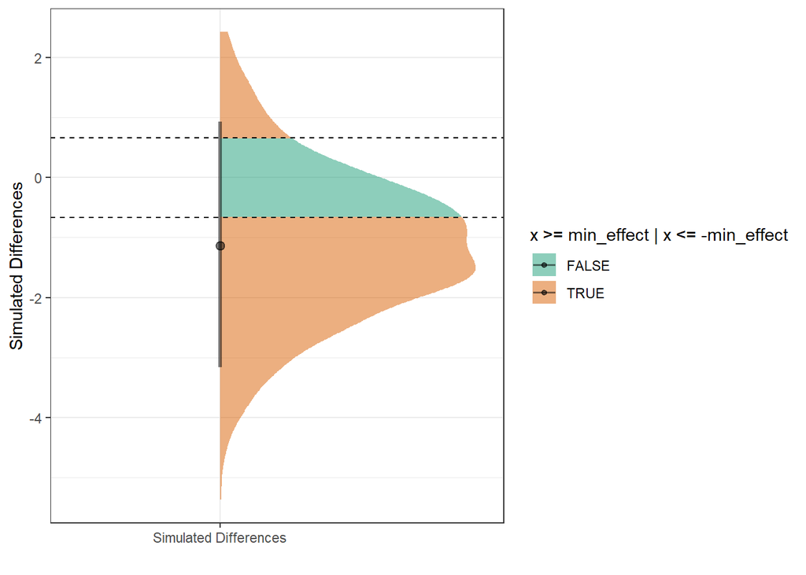

```r
booted<-inferences(comp, method='boot', conf_type = 'perc', R=1000)
draws<-get_draws(booted)
ggplot(draws, aes(x=draw, y='Simulated Differences'))+

   stat_halfeye(alpha=.5, .width = c(.90), aes(fill=after_stat(x>=min_effect | x<= -min_effect))) +
    geom_vline(xintercept=-min_effect, lty=2, col='black') +
    geom_vline(xintercept=min_effect, lty=2, col='black') +
  theme_bw() +
  scale_fill_brewer(palette='Dark2')+
  xlab("Simulated Differences") +
  ylab("")+
  coord_flip()
```

# Question 2

See if you can make improvements to the existing model by adding additional covariates, interaction effects, polynomials etc.